# Spotify Song Analytics

Joel Soroos

2020-05-02

### Motivation

Spotify is an amazing app to play favorite music, discover new music and rediscover old favorites. In addition, the Spotify API provides free access to a wide array of data on songs, which R users can leverage via Charlie Thompson’s [spotifyR package](https://www.rdocumentation.org/packages/spotifyr/versions/2.1.1). I wanted to learn more about my musical tastes while learning new R skills.

### 1. Activate Spotify connection

First step is to sign up for a [free Spotify API developer ID and secret token](https://developer.spotify.com/).

Second, you can either embed the Spotify login information directly in the script or assign to an enivronment variable. The advantage of an environment variable is your private login information will be stored on your computer. That way your R code can be shared without exposure to your login information being stolen. The [usethis package](https://community.rstudio.com/t/how-to-set-a-variable-in-renviron/5029/4) simplifies creating and updating environment variables.

```r
   library (spotifyr)

   access_token <- get_spotify_access_token(
      client_id=Sys.getenv("SPOTIFY_CLIENT_ID"),
      client_secret=Sys.getenv("SPOTIFY_CLIENT_SECRET")
      )
```

### 2a. Source favorite song statistics

I decided to focus my analysis on liked tracks (called “favorites” in the Spotify API). The favorite_tracks function extracts information such as song name, album name and artist(s).

The favorite_tracks function returns the output in an unwieldy list format that requires simplification to the more manageable data frame. The artist name creates multiple records per song because multiple artists can be assigned to individual songs. I simplified by unnesting the list so multiple rows per song for each artist.

```r
   library (tidyverse)

   favorite_tracks_stats <-
        ceiling(get_my_saved_tracks(include_meta_info = TRUE)[['total']] / 50) %>%
        seq() %>%
        map(function(x) {
          get_my_saved_tracks(
             limit = 50,
             offset = (x - 1) * 50)
            }) %>%
        reduce (rbind) %>%
        unnest (track.artists)      #simplifies list to multiple rows for tracks with two artists

   glimpse (favorite_tracks_stats)
```

```
## Rows: 170
## Columns: 35
## $ added_at                           <chr> "2020-04-23T11:14:07Z", "2020-04-2…
## $ href                               <chr> "https://api.spotify.com/v1/artist…
## $ id                                 <chr> "51Blml2LZPmy7TTiAg47vQ", "51Blml2…
## $ name                               <chr> "U2", "U2", "Ratt", "AC/DC", "Twis…
## $ type                               <chr> "artist", "artist", "artist", "art…
## $ uri                                <chr> "spotify:artist:51Blml2LZPmy7TTiAg…
## $ external_urls.spotify              <chr> "https://open.spotify.com/artist/5…
## $ track.available_markets            <list> [<"AD", "AE", "AR", "AT", "AU", "…
## $ track.disc_number                  <int> 1, 1, 1, 1, 1, 1, 1, 1, 1, 1, 1, 1…
## $ track.duration_ms                  <int> 279440, 295515, 265893, 210173, 21…
## $ track.explicit                     <lgl> FALSE, FALSE, FALSE, FALSE, FALSE,…
## $ track.href                         <chr> "https://api.spotify.com/v1/tracks…
## $ track.id                           <chr> "6C4LXC9UFH1IKiHYOp0BiJ", "6ADSaE8…
```

[output cut: 22 more lines]

### 2b. Source favorite song features

Song features such as energy, tempo and valence are stored in a separate Spotify API table so require a separate function. Full definitions are available on [Spotify’s developer site](https://github.com/rfordatascience/tidytuesday/blob/master/data/2020/2020-01-21/readme.md).

Spotify again limits the number of songs (to 100 in this case) but can be circumvented via a loop function that breaks into multiples of 100.

```r
   library (lubridate)

      favorite_tracks_ids <- favorite_tracks_stats %>%
         distinct (track.id) %>%       #eliminates duplicate rows by songs with > 1 artist (picks 1st)
         pull (track.id)

      favorite_tracks_features <-
         seq (1, nrow(favorite_tracks_stats),100) %>%
         map(function(x) {
             get_track_audio_features (favorite_tracks_ids[x:(x+99)])   #circumvents max of 100 track IDs
               }) %>%
         reduce(rbind) %>%             #simplifies list and appends previously nested frames
         drop_na()

      glimpse (favorite_tracks_features)
```

```
## Rows: 159
## Columns: 18
## $ danceability     <dbl> 0.543, 0.540, 0.628, 0.532, 0.502, 0.694, 0.809, 0.5…
## $ energy           <dbl> 0.944, 0.429, 0.934, 0.767, 0.924, 0.724, 0.907, 0.9…
## $ key              <int> 6, 2, 11, 7, 4, 5, 1, 7, 7, 6, 8, 0, 2, 2, 2, 1, 4, …
## $ loudness         <dbl> -7.495, -11.822, -6.026, -5.509, -6.299, -8.125, -3.…
## $ mode             <int> 1, 1, 1, 1, 1, 1, 1, 1, 1, 1, 1, 1, 0, 1, 1, 1, 1, 1…
## $ speechiness      <dbl> 0.0543, 0.0285, 0.0527, 0.0574, 0.0503, 0.0282, 0.09…
## $ acousticness     <dbl> 0.402000, 0.000202, 0.006820, 0.002870, 0.012700, 0.…
## $ instrumentalness <dbl> 5.64e-04, 3.55e-01, 1.11e-05, 5.13e-04, 0.00e+00, 3.…
## $ liveness         <dbl> 0.0373, 0.1410, 0.0852, 0.3900, 0.1620, 0.1380, 0.04…
## $ valence          <dbl> 0.7350, 0.1130, 0.4910, 0.7550, 0.9220, 0.8440, 0.96…
## $ tempo            <dbl> 101.174, 110.171, 126.538, 127.361, 149.186, 119.313…
## $ type             <chr> "audio_features", "audio_features", "audio_features"…
## $ id               <chr> "6C4LXC9UFH1IKiHYOp0BiJ", "6ADSaE87h8Y3lccZlBJdXH", …
## $ uri              <chr> "spotify:track:6C4LXC9UFH1IKiHYOp0BiJ", "spotify:tra…
## $ track_href       <chr> "https://api.spotify.com/v1/tracks/6C4LXC9UFH1IKiHYO…
## $ analysis_url     <chr> "https://api.spotify.com/v1/audio-analysis/6C4LXC9UF…
## $ duration_ms      <int> 279440, 295516, 265893, 210173, 219667, 347507, 1324…
## $ time_signature   <int> 4, 4, 4, 4, 4, 4, 4, 4, 4, 4, 4, 4, 4, 4, 4, 4, 4, 4…
```

### 2c. Combine song features and statistics

Spotify assigns an alphanumeric ID code for each song. The ID is in both the statistics and attributes tables so the two tables can be joined together.

A few other housekeeping items are required before proceeding to the the chart. First, Song duration is clearer in minutes instead of milliseconds. Second, I cleaned song titles by removing “Remaster”, “Remastered” as well as parenthetical qualifiers. Third, I converted album release year to number of years past 1980 to better visually discern year differences (bar charts typically start at zero).

```r
      favorite_tracks_combine <- favorite_tracks_features %>%#removes N/As resulting from liked song totals less than 100 multiple
         right_join(favorite_tracks_stats, by = c("id" = "track.id")) %>%
         rename (artist.name = name) %>%
         mutate (
            duration = duration_ms / 1000 / 60,                      #converts milliseconds to minutes
            track.name = str_remove (track.name, c("Remaster", "Remastered")),
            track.name = str_remove (track.name,"[(-].+"),
            track.name = ifelse (str_length (track.name) <= 22, track.name, str_extract(track.name, "^.{22}")),
            release = ifelse (
               track.album.release_date_precision == "year",         #some songs only lists years not dates
               as.integer(track.album.release_date),
               year(as_date(track.album.release_date))
               ),
            release = release - 1980                            #enables bar charts to start at 0
            ) %>%
         select (artist.name, track.name, danceability, energy, valence, tempo, duration, release) %>%
         distinct (track.name, .keep_all = T)

      glimpse (favorite_tracks_features)
```

```
## Rows: 159
## Columns: 18
## $ danceability     <dbl> 0.543, 0.540, 0.628, 0.532, 0.502, 0.694, 0.809, 0.5…
## $ energy           <dbl> 0.944, 0.429, 0.934, 0.767, 0.924, 0.724, 0.907, 0.9…
## $ key              <int> 6, 2, 11, 7, 4, 5, 1, 7, 7, 6, 8, 0, 2, 2, 2, 1, 4, …
## $ loudness         <dbl> -7.495, -11.822, -6.026, -5.509, -6.299, -8.125, -3.…
## $ mode             <int> 1, 1, 1, 1, 1, 1, 1, 1, 1, 1, 1, 1, 0, 1, 1, 1, 1, 1…
## $ speechiness      <dbl> 0.0543, 0.0285, 0.0527, 0.0574, 0.0503, 0.0282, 0.09…
## $ acousticness     <dbl> 0.402000, 0.000202, 0.006820, 0.002870, 0.012700, 0.…
## $ instrumentalness <dbl> 5.64e-04, 3.55e-01, 1.11e-05, 5.13e-04, 0.00e+00, 3.…
## $ liveness         <dbl> 0.0373, 0.1410, 0.0852, 0.3900, 0.1620, 0.1380, 0.04…
## $ valence          <dbl> 0.7350, 0.1130, 0.4910, 0.7550, 0.9220, 0.8440, 0.96…
## $ tempo            <dbl> 101.174, 110.171, 126.538, 127.361, 149.186, 119.313…
## $ type             <chr> "audio_features", "audio_features", "audio_features"…
## $ id               <chr> "6C4LXC9UFH1IKiHYOp0BiJ", "6ADSaE87h8Y3lccZlBJdXH", …
## $ uri              <chr> "spotify:track:6C4LXC9UFH1IKiHYOp0BiJ", "spotify:tra…
## $ track_href       <chr> "https://api.spotify.com/v1/tracks/6C4LXC9UFH1IKiHYO…
## $ analysis_url     <chr> "https://api.spotify.com/v1/audio-analysis/6C4LXC9UF…
## $ duration_ms      <int> 279440, 295516, 265893, 210173, 219667, 347507, 1324…
## $ time_signature   <int> 4, 4, 4, 4, 4, 4, 4, 4, 4, 4, 4, 4, 4, 4, 4, 4, 4, 4…
```

### 3a. Create charts by feature

Bars represent the top 5 and bottom 5 songs for each attribute. The bottom rug illustrates the full dispersion.

A map function creates the separate charts for each attribute. The simpler ggplot facet function generates charts via filtering but cannot sort by variable.

```r
   library (glue)

   #define variables to parse charts
      attributes <- c("valence", "energy", "tempo", "danceability", "duration", "release")

   #function to create bar chart for dynamic variable
      attributes_plot = function(attribute) {
         attribute = ensym (attribute)
         ggplot (
               data = favorite_tracks_combine %>%
                  arrange (-!!attribute) %>%
                  slice (1:5, (n()-4):n()) %>%
                  mutate (bar_color = ifelse (!!attribute > median (!!attribute), "Lightgreen", "Red")),
               aes (x = reorder (track.name, !!attribute), y = !!attribute),
               size = 1
               ) +
            geom_point (
               aes(color = I(bar_color)),
               shape = 19
               ) +
            geom_segment (
               aes(
                  xend = reorder (track.name, !!attribute), y = 0, yend = !!attribute,
                  color = I(bar_color)
                  )
               ) +
            geom_rug (
               data = favorite_tracks_combine,
               aes (y = !!attribute),
               inherit.aes = F,
               sides = "l",
               alpha = 0.3
               ) +
            scale_y_continuous (n.breaks = 4) +
            coord_flip () +
            theme(
               plot.title = element_text(hjust = 0.5, vjust = 0, size = 10, face = "bold", margin = margin (10,0,10,0)),
               axis.text = element_text (size = 8),
               axis.title = element_blank(),
               axis.ticks = element_blank(),
               panel.grid = element_blank(),
               panel.background = element_blank()
               ) +
          labs (
             title = glue({str_to_title(attribute)})
             )
      }

   #create charts for each attribute
   song_plots <- map(attributes, attributes_plot)
```

### 3b. Combine charts, add titles/subtitles/captions

My favorite chart combination package is Thomas Lin Pederson’s excellent [patchwork](https://www.rdocumentation.org/packages/patchwork/versions/1.0.0) package. Charts automatically are aligned vertically and/or horizontally. I have six charts so by default patchwork prints the first three charts on top row then second three on bottom row.

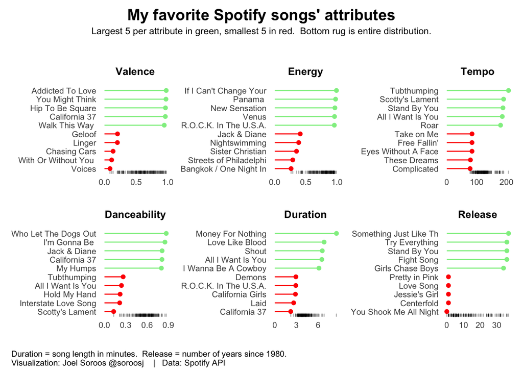

```r
   library (patchwork)

   #combine charts into grid
      song_plots_combine <-
         song_plots[[1]] + song_plots[[2]] + song_plots[[3]] + song_plots[[4]] + song_plots[[5]] + song_plots[[6]] +
         plot_annotation (
            title =  "My favorite Spotify songs' attributes",
            subtitle = "Largest 5 per attribute in green, smallest 5 in red.  Bottom rug is entire distribution.",
            caption = "Duration = song length in minutes.  Release = number of years since 1980.  \nVisualization: Joel Soroos @soroosj    |   Data: Spotify API",
            theme = theme (
               plot.title = element_text(hjust = 0.5, vjust = 0, size = 15, face = "bold", margin = margin (0,0,5,0)),
               plot.title.position = "plot",
               plot.subtitle = element_text(hjust = 0.5, vjust = 0, size = 9, margin = margin (0,0,15,0)),
               plot.caption = element_text (hjust = 0, size = 8, face = "plain", margin = margin (15,0,0,0)),
               plot.caption.position = "plot"
               )
            )

      ggsave("song_attributes.png", song_plots_combine)
      song_plots_combine
```